# Eco-Site Group Climate Optimization V2

Travis Nauman

August 12, 2020

### Description of Optimization

After grouping all ecological sites into soil-geomorphic units (SGUs) by reviewing recent papers, analyzing productivity data, and soliciting feedback from BLM staff, we needed a quantitative way to look at multiple climate parameters for grouping. This analysis looks at using aridity index (AI), maximum temperature of the warmest month (maxt), minimum temperature of the coldest month, and ratio the ratio warm season (June-Sept) to annual precipitation (pptratio). The AI data was from Trabucco and Zomer (2009), temperature data from Fick and Hijmans (2017), and the precipitation data was from PRISM. All climate data was summarized for all SSURGO polygons, and then averaged by ecological site. Reference state production was then averaged as the response variable matrix with the following variables.

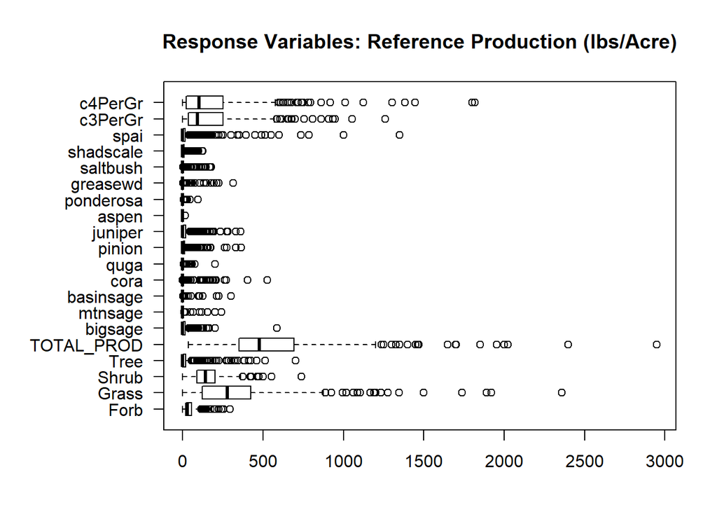

## Explanatory Variables: Climate and SGUs with tested group breaks

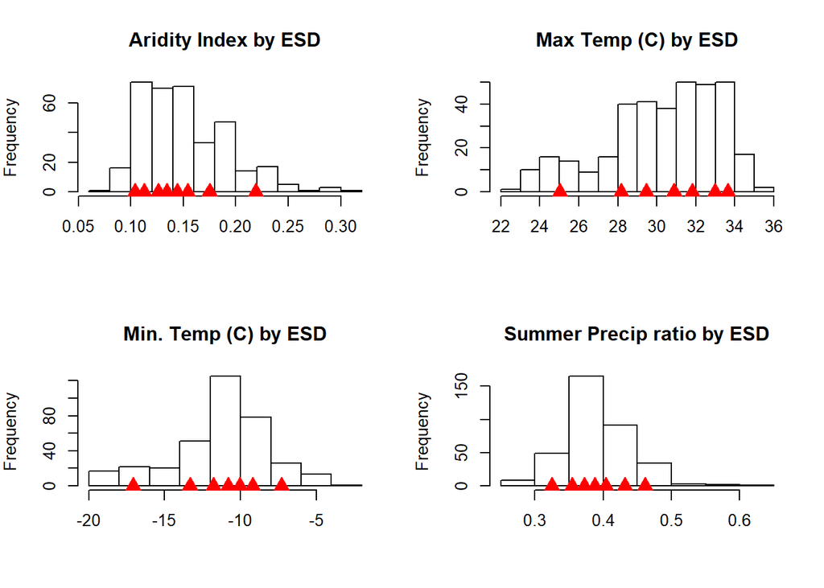

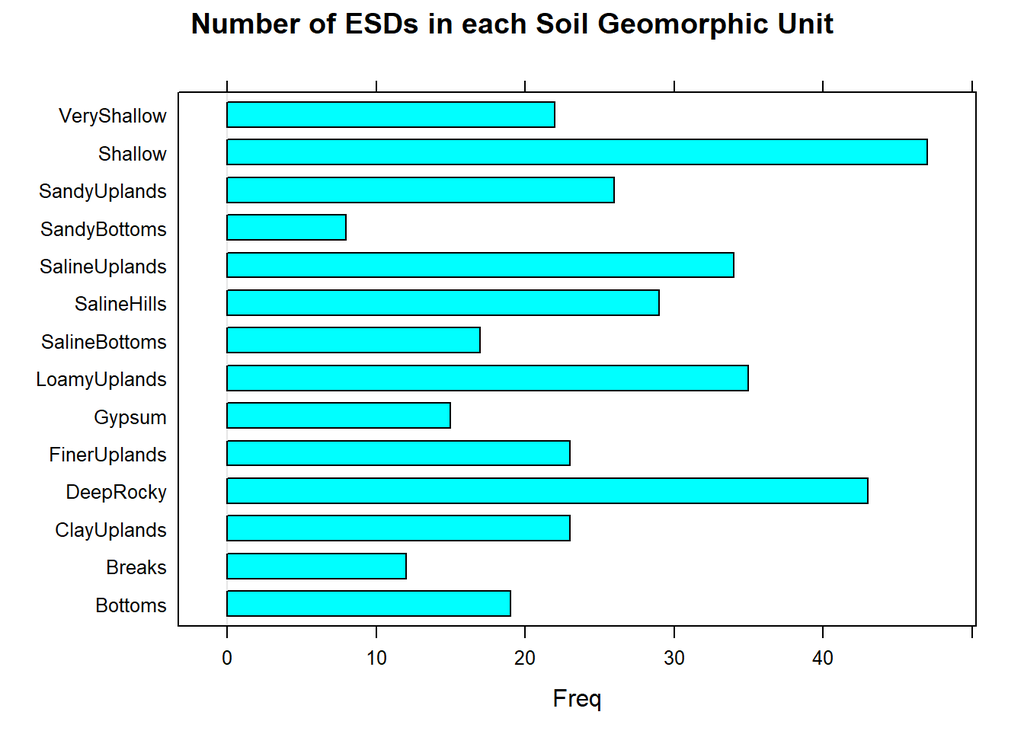

The challenge is to maximize differences in the Production parameters using a minimal number of splits in the climate data and SGUs. Splits tested are shown by the red triangles on the histograms.

### PerManova test on full dataset with continuous variables

Before creating the potential groupings. I ran a perManova test using Bray-Curtis distance with the adonis() function of the vegan package. This is a non-parametric version of ANOVA that is run when you have more than one response variable.

```
## [1] "perManova with no interactions"
```

```
## Permutation test for adonis under reduced model
## Marginal effects of terms
## Permutation: free
## Number of permutations: 999
##
## adonis2(formula = daty ~ sgu + ai + maxt + mint + pptrt, data = datx, permutations = 999, method = "bray", by = "margin", parallel = cpus)
##           Df SumOfSqs      R2       F Pr(>F)
## sgu       13    9.755 0.24998 11.5209  0.001 ***
## ai         1    0.697 0.01786 10.6998  0.001 ***
## maxt       1    0.262 0.00671  4.0206  0.008 **
## mint       1    0.460 0.01178  7.0565  0.001 ***
## pptrt      1    0.833 0.02135 12.7943  0.001 ***
## Residual 335   21.820 0.55913
## Total    352   39.024 1.00000
## ---
## Signif. codes:  0 '***' 0.001 '**' 0.01 '*' 0.05 '.' 0.1 ' ' 1
```

```
## [1] "perManova with all 2x interactions"
```

```
## Permutation test for adonis under reduced model
## Marginal effects of terms
## Permutation: free
## Number of permutations: 999
##
## adonis2(formula = daty ~ sgu + sgu:ai + sgu:maxt + sgu:mint + sgu:pptrt, data = datx, permutations = 999, method = "bray", by = "margin", parallel = cpus)
##            Df SumOfSqs      R2      F Pr(>F)
## sgu:ai     14    1.544 0.03957 1.8329  0.003 **
## sgu:maxt   14    1.252 0.03208 1.4858  0.019 *
## sgu:mint   14    1.160 0.02972 1.3767  0.060 .
## sgu:pptrt  14    1.883 0.04825 2.2350  0.001 ***
## Residual  283   17.029 0.43638
## Total     352   39.024 1.00000
## ---
## Signif. codes:  0 '***' 0.001 '**' 0.01 '*' 0.05 '.' 0.1 ' ' 1
```

Models show all the individual response variables to be influential in explaining variation in the responses. Many interactions are significant, but note that very few variables explain much of the variance except for the SGUs (25%). Aridity index and monsoon precipitation ratio explains roughly 2% of variation and about 1% of variation is explained by both min and max temperatures. Given that all variables had some kind of influence, breaks from all indepedent variables were indcluded in the climate grouping optimization. When interactions are explored varation explained goes from 0.44 (SGUs plus climate variables) to 0.56 when adding 2-way interactions of each climate variables with SGUs.

### Visualizing patterns in ordination

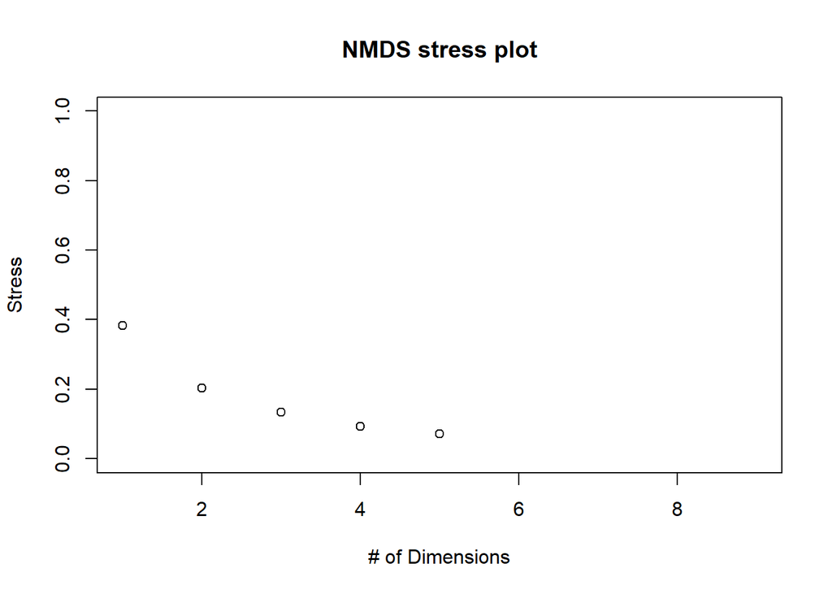

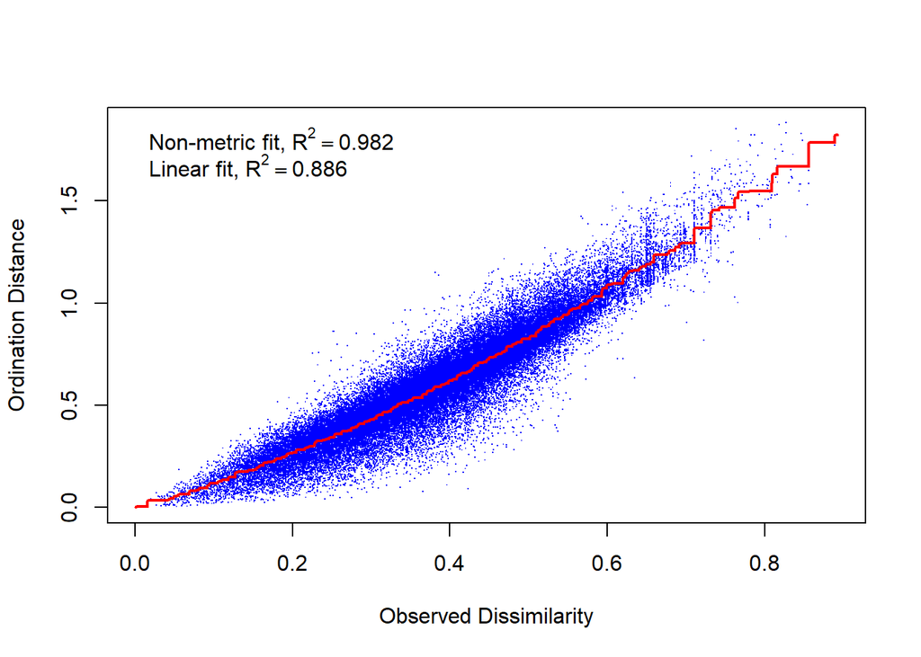

The stress for this ordination is 0.1340441.

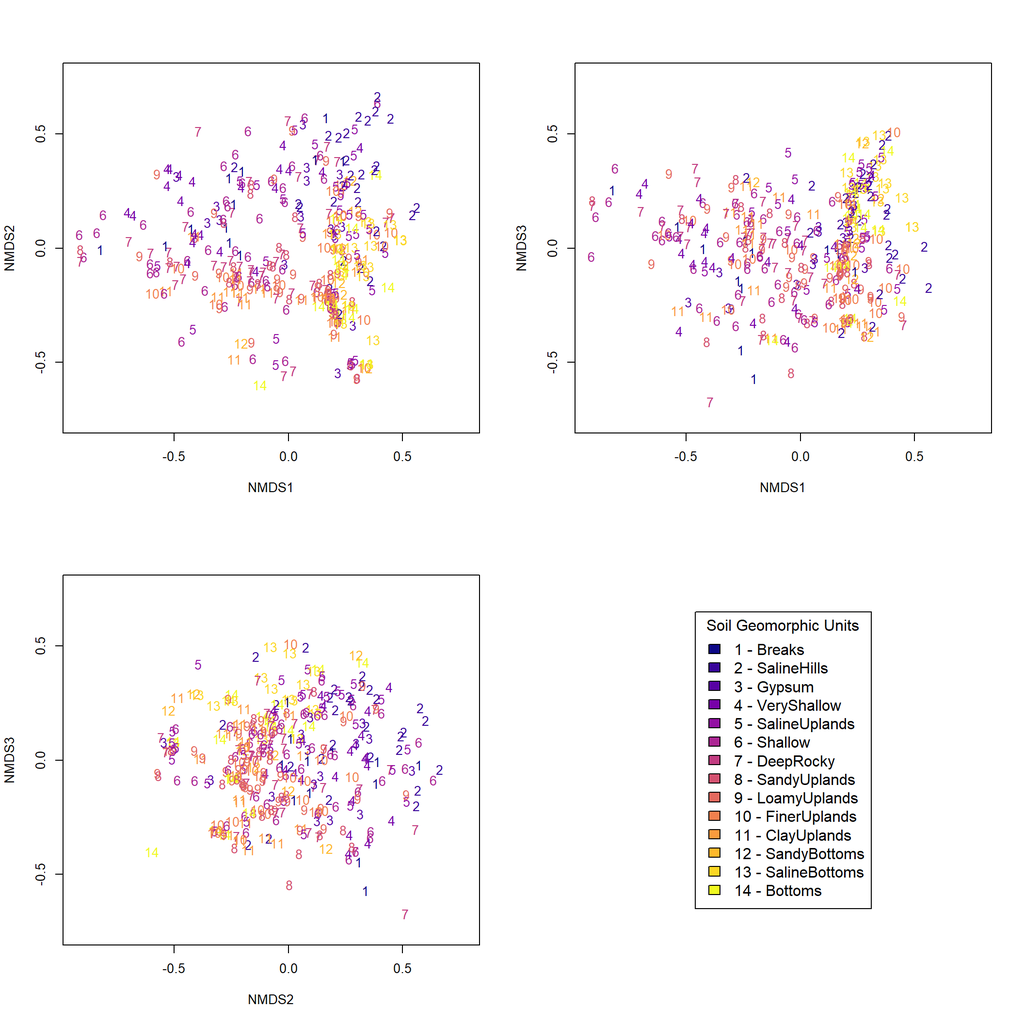

Figure 1. 3D ordination of vegetation Production Data.

### Climate-SGU grouping optimization

Two main workflows were used to look for a good grouping scheme. The nested scheme first chose the best climate breaks without any aggregation of SGUs, then tested nested combinations of SGU aggregation to test the hypothesis that SGUs may need to be more aggregated in wetter/cooler climate zones. Another scheme looked at overlaying all potential breaks for all variables simultaneously essentially treating the variables independently of each other with aggregation of SGU independent of climate. Information theoretics were used to look at relative model strenth using a residuals implementation of AICc for small sample size. The distribution of AICc and associated Akaike weights were used to rank models by balancing model fit with the number of groups. Below is the initial testing of climate breaks with no SGU aggregation. You can see that Rsq increases with number of groups, while the F-ratio decreases with sample size due to less degrees of freedom. The AICc value balances these metrics and Akaike weight help determine how much emphasis can be placed on a given model when thinking about a population of candidate models.The goal is to minimize AICc value.

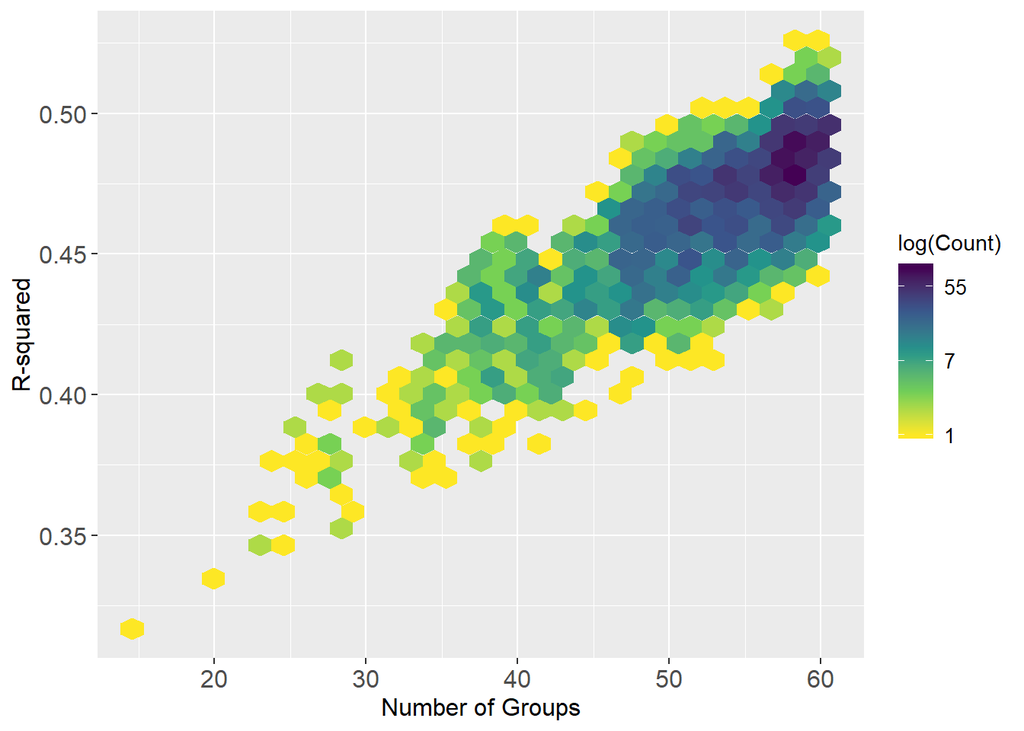

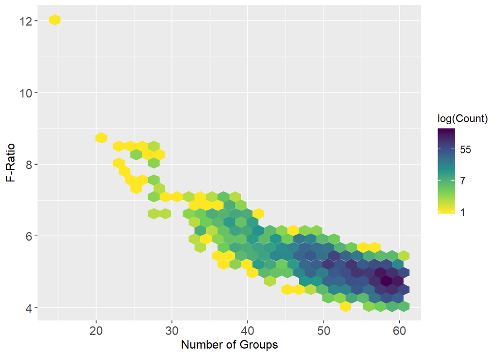

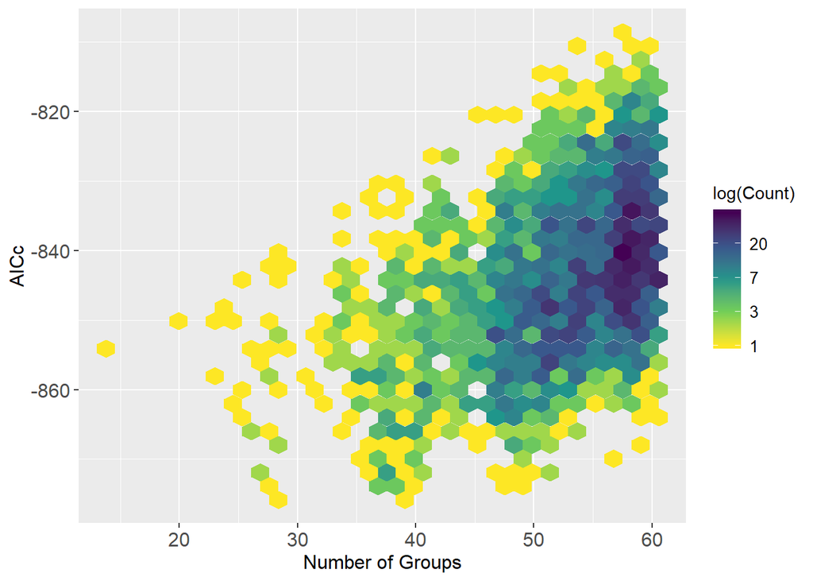

These figures illustrate how AIC balances fit with number of groups for the initial test of climate variable splits with no SGU aggregation.

## Nested grouping

In this approach climate breaks are identified first (figures above) in an optimization without any SGU aggregation, then the best climate breaks are tested for varying aggregation of SGUs in nested optimization tests. Top climate models were then selected using AICc criteria for testing various nested SGU models.

Version 2: Top ten climate models

| numgrps | Rsq | AICc | AICcWt | AICcrelLL |
| --- | --- | --- | --- | --- |
| 28 | 0.41 | -876.69 | 0.15 | 1.00 |
| 39 | 0.46 | -875.57 | 0.08 | 0.57 |
| 37 | 0.45 | -874.93 | 0.06 | 0.42 |
| 38 | 0.45 | -874.80 | 0.06 | 0.39 |
| 38 | 0.45 | -874.65 | 0.05 | 0.36 |
| 48 | 0.49 | -873.81 | 0.04 | 0.24 |
| 28 | 0.41 | -873.70 | 0.03 | 0.22 |
| 49 | 0.49 | -873.69 | 0.03 | 0.22 |
| 39 | 0.45 | -873.62 | 0.03 | 0.22 |
| 37 | 0.45 | -873.43 | 0.03 | 0.20 |

This table shows the AICc summary of the climate breaks. The AICc does drop off quickly in the top five and many of the 5-10th best models had similar climate breaks to the top four, but in different combiation. So, I focused on the top 4 models that represented the most common climate breaks in the top 10 models while also sticking to the best AICc results. All top ten models included AI splits (mostly 0.144, couple with 0.104, and couple with 0.134), three of the models had min temp splits (all -17.07), four had max temp splits (25 for 3 and 28.17 for one), and none of the top ten models had monsoon ratio breaks. The top climate trial was also the simplest (only one AI split), and was tested first with a set of viable SGU combinations with up to 4 classes aggregated (same as v1). Combos allowed: c(‘1,2’,‘1,3’,‘1,4’,‘2,3’,‘2,4’,‘2,5’,‘3,4’,‘3,5’,‘4,5’,‘4,6’,‘4,7’,‘5,6’,‘5,7’,‘5,8’,‘5,9’,‘6,7’,‘7,8’,‘8,12’,‘8,9’,‘9,10’,‘9,12’,‘10,11’,‘12,13’,‘12,14’,‘13,14’). Then the more complicated nested models used subsetted from those SGU groupings based on relLL >0.50 with >5% occurence to narrow down SGU combos for computational feasibility (100s of millions of combinations were tested).

## Simultaneous grouping

In this approach, all possible combinations of splits were tested simultaneously with SGUs and climate parameters. For selection of these breaks all combintions of 0-3 possible breaks were allowed for AI and 0-2 breaks were allowed for max temp, min temp and pptratio. For SGUs, all groups could be retained, but up to four groups could also be aggregated together (or 3 groups of two, or 1 group of 2 and one group of three). Due to large possible numbers of combiations, SGU groupings were limited to those with 5% occurrance of models with >0.5 AIC relative likelihood in trials testing SGU groupings nested within best identified climate breaks identified before testing of SGU combinations (‘1,3’,‘1,4’,‘3,4’,‘5,9’,‘6,7’,‘7,8’,‘8,9’,‘9,10’,‘10,11’,‘12,13’,‘12,14’,‘13,14’).

## Comparing climate-SGU models across trial versions.

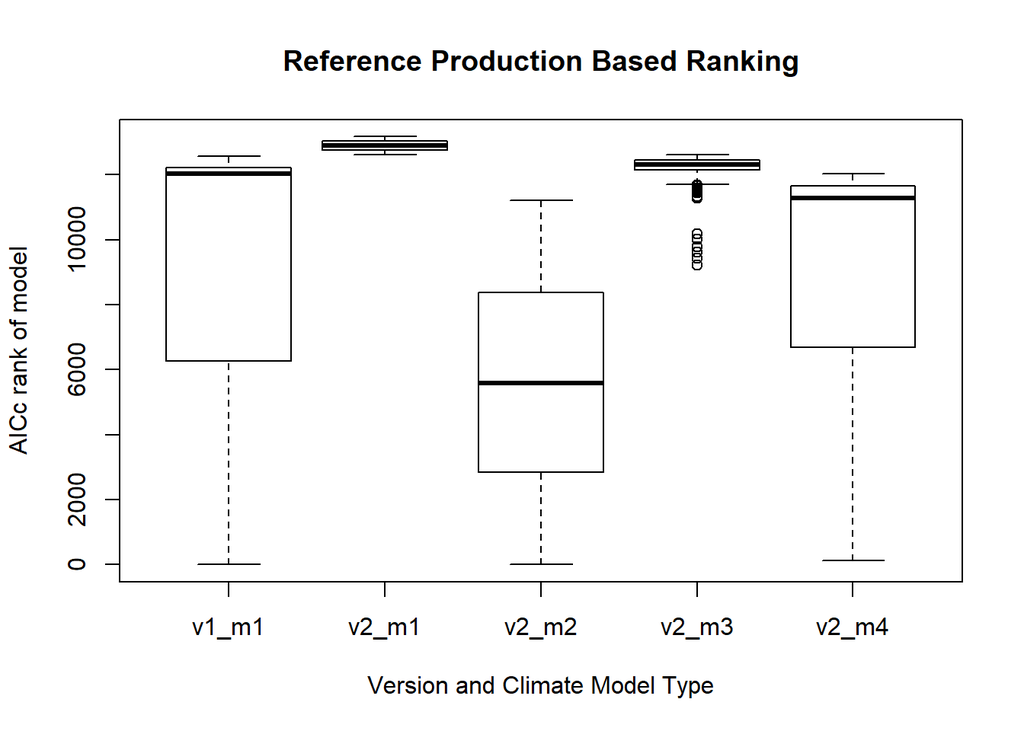

Nested models selected many combinations of climate breaks, with much commonaility to simultaneous groupings, so a broader AICc analysis was required to narrow models down. All nested models has more dispersed AICc values meaning there were more viable candidates while simultaneous grouping had a more clear concentration of better model candidates. As such, all nested models with relLL >0.5 were included, while only relLL >0.1 were included from the simultaneously grouped models. The boxplot clearly shows that v1_m1, v2_m2, and v2_m4 trials had the best possible candidate models when looking at the reference production parameters. However, all of these models were then analyzed using the ESD level STM data to help choose a final eco site group schema.

### Comparing all versions all models using STM state data

## Full STM: Top ten models

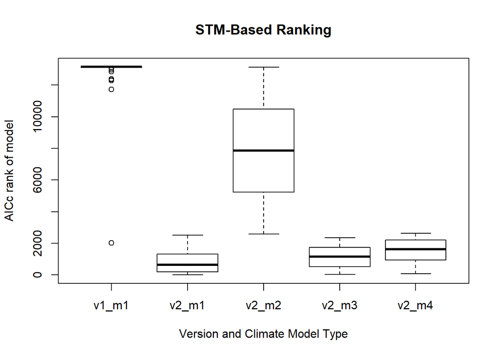

STM ranking based on AICc results is quite different from the reference production data with version 1 performing the worse by far. The overall goal is to maximize both the reference data and STM data rankings. When digging into the rankings of individual models that ranked high in both, model v2_m4_26 was selected as the top candidate because v2_m4 trials were the only ones to score high in both reference and STM trials. This model nested sgu aggregations into 3 climate groups:

1. Areas with AI < 0.144 and max temp > 25.02C: Arid-Warm
2. Areas with AI > 0.144 and max temp > 25.02C: Semiarid-Warm
3. Areas with AI > 0.144 and max temp < 25.02C: Semiarid-Cool

### Examining the Top Model

```
## Permutation test for adonis under NA model
## Marginal effects of terms
## Permutation: free
## Number of permutations: 999
##
## adonis2(formula = daty ~ esg, data = datx, permutations = 999, method = "bray", by = "margin")
##           Df SumOfSqs      R2      F Pr(>F)
## esg       28   18.528 0.44811 9.3954  0.001 ***
## Residual 324   22.819 0.55189
## Total    352   41.346 1.00000
## ---
## Signif. codes:  0 '***' 0.001 '**' 0.01 '*' 0.05 '.' 0.1 ' ' 1
```

The resulting Eco-site groups explained 45% of the variation, a 21% increase from just the SGUs.

## Looking at production metrics for final ESGs and the original SGUs

The coding for ESGs used below goes like this ‘4_2_2_1_1_8,9’ where 4 is the fourth climate model, the following 2 is the aridity class, the next 2 is the max temp class, the next two 1s are the min temp and precip ratio classes (all are ’1’s in final model due to no breaks), and the last value or tuple of values are the SGU codes. Values are sequential (e.g. a 1 for aridity class means the lowest AI values).

[1] “ESGs include the following SGUs aggregated by climate group: Arid-Warm - c("8,9", "10,11", "13,14") ; Semiarid-Warm - c("6,7", "8,9", "12,14") ; Semiarid-Cool - 5,8,9,10”

SGU Reference

| sgu | sgulev |
| --- | --- |
| Breaks | 1 |
| SalineHills | 2 |
| Gypsum | 3 |
| VeryShallow | 4 |
| SalineUplands | 5 |
| Shallow | 6 |
| DeepRocky | 7 |
| SandyUplands | 8 |
| LoamyUplands | 9 |
| FinerUplands | 10 |
| ClayUplands | 11 |
| SandyBottoms | 12 |
| SalineBottoms | 13 |
| Bottoms | 14 |

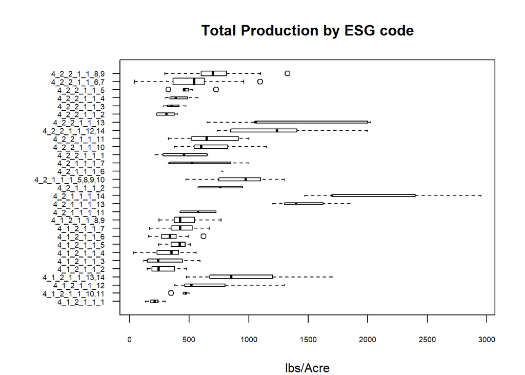

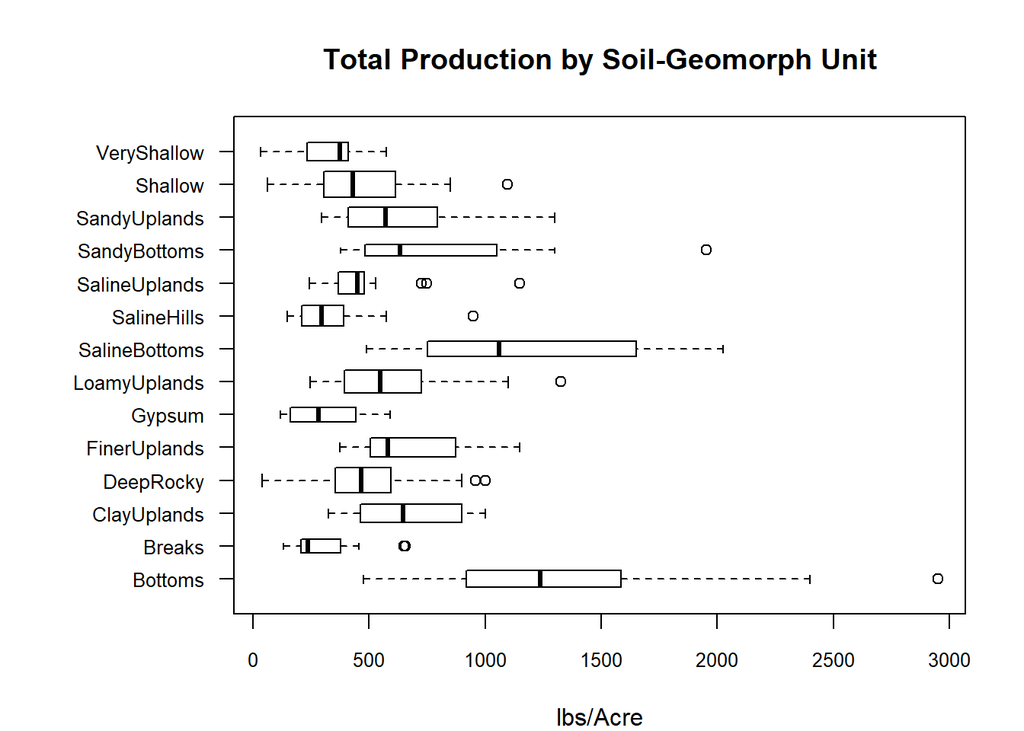

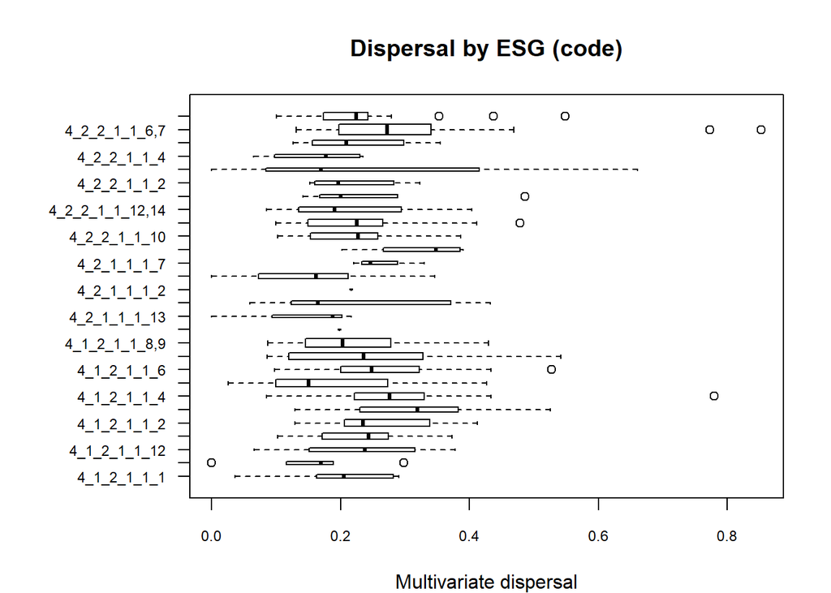

Boxplots reveal high variation of total production between the ESGs and relatively similar dispersion between groups in multivariate space with only weak evidence of heterogeneity (p=0.05). Examination of the data does indicate that groups differ both by both differences in central tendencies of the groups with respect to dependent variables and by differences in dispersion. Given with the dependent variables chosen, we would expect groups to have overlap (e.g., we expect most groups to have some amount of grass production) that limit variance explained and that may be more variable in some groups.

### Production ordination of chosen Climate-SGU (ESG) schema

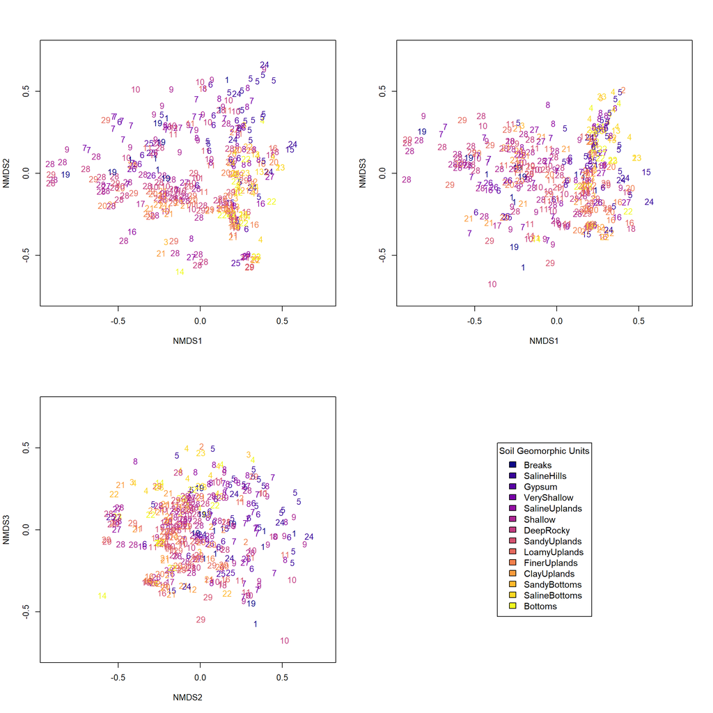

Figure 2. 3D ordination of vegetation Production Data with ESGs (numbered.

### Examining STM and production data for new Eco Site Groups and Compare with original SGUs

States are encoded with an initial letter for type of state and then the detail of that state. r-reference, i-invasion, e-encroachment, er-erosion, b-bareground, pl-perrenial species loss.

Heatmap: Proportion of ESDs with State

| v2_m4_26 | r.dune | r.grass | r.wl | r.wet | r.shrub | i.bromus | i.salsola | i.halo | i.wheat | i.blue | i.oth | inon.bun | inon.oth | e.sna | e.rab | e.shad | e.grea | e.tam | e.rus | e.opt | e.pin | e.jun | e.sage | e.shrub | e.tree | e.oth | er.dune | er.rill | er.oth | … |
| --- | --- | --- | --- | --- | --- | --- | --- | --- | --- | --- | --- | --- | --- | --- | --- | --- | --- | --- | --- | --- | --- | --- | --- | --- | --- | --- | --- | --- | --- | --- |
| 4_1_2_1_1_1 | 0.00 | 0.00 | 0.00 | 0.00 | 1.00 | 0.83 | 0.67 | 0.17 | 0.00 | 0.00 | 1.00 | 0.00 | 0.00 | 0.17 | 0.00 | 0.00 | 0.00 | 0.00 | 0.00 | 0.00 | 0.00 | 0.00 | 0.00 | 0.00 | 0.00 | 0.00 | 0.00 | 0.00 | 0.00 | … |
| 4_1_2_1_1_10,11 | 0.00 | 0.75 | 0.00 | 0.00 | 0.25 | 1.00 | 0.50 | 0.50 | 0.00 | 0.00 | 0.75 | 0.00 | 0.00 | 0.25 | 0.50 | 0.75 | 0.00 | 0.25 | 0.00 | 0.00 | 0.00 | 0.00 | 0.25 | 1.00 | 0.25 | 0.50 | 0.00 | 0.25 | 0.00 | … |
| 4_1_2_1_1_12 | 0.00 | 0.67 | 0.00 | 0.00 | 0.67 | 0.67 | 0.33 | 0.00 | 0.00 | 0.00 | 1.00 | 0.33 | 0.00 | 0.33 | 0.33 | 0.33 | 0.33 | 0.00 | 0.00 | 0.00 | 0.00 | 0.00 | 0.00 | 1.00 | 0.00 | 0.67 | 0.00 | 0.00 | 0.00 | … |
| 4_1_2_1_1_13,14 | 0.00 | 0.40 | 0.00 | 0.10 | 0.70 | 0.50 | 0.30 | 0.10 | 0.10 | 0.10 | 1.00 | 0.00 | 0.00 | 0.20 | 0.20 | 0.20 | 0.50 | 0.50 | 0.10 | 0.00 | 0.00 | 0.00 | 0.10 | 0.70 | 0.50 | 0.40 | 0.00 | 0.20 | 0.10 | … |
| 4_1_2_1_1_2 | 0.00 | 0.31 | 0.00 | 0.00 | 0.77 | 0.69 | 0.85 | 0.31 | 0.00 | 0.00 | 0.92 | 0.00 | 0.00 | 0.38 | 0.31 | 0.46 | 0.15 | 0.00 | 0.00 | 0.00 | 0.00 | 0.08 | 0.08 | 0.69 | 0.08 | 0.46 | 0.00 | 0.00 | 0.31 | … |
| 4_1_2_1_1_3 | 0.00 | 0.00 | 0.00 | 0.00 | 1.00 | 0.50 | 0.33 | 0.00 | 0.00 | 0.00 | 0.83 | 0.00 | 0.00 | 0.33 | 0.33 | 0.00 | 0.00 | 0.00 | 0.00 | 0.00 | 0.00 | 0.00 | 0.00 | 0.33 | 0.00 | 0.00 | 0.00 | 0.00 | 0.00 | … |
| 4_1_2_1_1_4 | 0.00 | 0.06 | 0.44 | 0.00 | 0.56 | 0.50 | 0.31 | 0.00 | 0.00 | 0.00 | 0.69 | 0.06 | 0.00 | 0.25 | 0.12 | 0.00 | 0.00 | 0.00 | 0.00 | 0.06 | 0.00 | 0.00 | 0.06 | 0.38 | 0.00 | 0.12 | 0.00 | 0.00 | 0.12 | … |
| 4_1_2_1_1_5 | 0.00 | 0.69 | 0.00 | 0.00 | 0.46 | 0.46 | 0.38 | 0.23 | 0.00 | 0.00 | 0.69 | 0.08 | 0.00 | 0.23 | 0.15 | 0.46 | 0.00 | 0.00 | 0.00 | 0.00 | 0.08 | 0.08 | 0.00 | 0.54 | 0.08 | 0.38 | 0.00 | 0.00 | 0.00 | … |
| 4_1_2_1_1_6 | 0.00 | 0.15 | 0.15 | 0.00 | 0.77 | 0.69 | 0.69 | 0.23 | 0.00 | 0.00 | 0.85 | 0.00 | 0.00 | 0.38 | 0.08 | 0.15 | 0.00 | 0.00 | 0.00 | 0.08 | 0.00 | 0.00 | 0.08 | 0.69 | 0.00 | 0.46 | 0.00 | 0.00 | 0.08 | … |
| 4_1_2_1_1_7 | 0.00 | 0.08 | 0.17 | 0.00 | 0.83 | 0.50 | 0.42 | 0.00 | 0.00 | 0.00 | 0.75 | 0.00 | 0.00 | 0.25 | 0.17 | 0.00 | 0.00 | 0.00 | 0.00 | 0.08 | 0.08 | 0.17 | 0.25 | 0.42 | 0.25 | 0.08 | 0.00 | 0.00 | 0.08 | … |
| 4_1_2_1_1_8,9 | 0.13 | 0.65 | 0.04 | 0.00 | 0.83 | 0.70 | 0.52 | 0.00 | 0.04 | 0.00 | 0.87 | 0.00 | 0.00 | 0.74 | 0.52 | 0.04 | 0.00 | 0.00 | 0.00 | 0.09 | 0.04 | 0.26 | 0.43 | 0.78 | 0.39 | 0.26 | 0.04 | 0.04 | 0.13 | … |
| 4_2_1_1_1_11 | 0.00 | 0.50 | 0.00 | 0.00 | 0.50 | 0.50 | 0.50 | 0.00 | 0.00 | 0.50 | 0.50 | 0.00 | 0.00 | 0.00 | 0.50 | 0.00 | 0.00 | 0.00 | 0.00 | 0.00 | 0.00 | 0.00 | 0.50 | 1.00 | 0.00 | 0.00 | 0.00 | 0.00 | 0.50 | … |
| 4_2_1_1_1_13 | 0.00 | 0.33 | 0.00 | 0.00 | 0.67 | 0.00 | 0.00 | 0.00 | 0.00 | 0.00 | 0.00 | 0.00 | 0.00 | 0.00 | 0.00 | 0.00 | 1.00 | 0.00 | 0.00 | 0.00 | 0.00 | 0.00 | 0.00 | 1.00 | 0.00 | 0.00 | 0.00 | 0.00 | 0.00 | … |
| 4_2_1_1_1_14 | 0.00 | 0.80 | 0.00 | 0.00 | 0.20 | 0.00 | 0.00 | 0.00 | 0.00 | 0.20 | 0.60 | 0.00 | 0.00 | 0.00 | 0.40 | 0.00 | 0.00 | 0.40 | 0.00 | 0.00 | 0.00 | 0.00 | 0.40 | 0.40 | 0.40 | 0.20 | 0.00 | 0.00 | 0.00 | … |
| 4_2_1_1_1_2 | 0.00 | 0.00 | 0.00 | 0.00 | 1.00 | 0.50 | 0.00 | 0.50 | 0.00 | 0.00 | 0.50 | 0.50 | 0.00 | 0.00 | 0.00 | 0.00 | 0.00 | 0.00 | 0.00 | 0.00 | 0.00 | 0.00 | 0.50 | 0.50 | 0.00 | 1.00 | 0.00 | 0.00 | 0.00 | … |
| 4_2_1_1_1_5,8,9,10 | 0.00 | 0.80 | 0.00 | 0.00 | 0.20 | 0.40 | 0.10 | 0.00 | 0.10 | 0.10 | 0.20 | 0.20 | 0.00 | 0.00 | 0.70 | 0.00 | 0.00 | 0.00 | 0.00 | 0.00 | 0.00 | 0.10 | 0.70 | 0.90 | 0.10 | 0.00 | 0.00 | 0.00 | 0.00 | … |
| 4_2_1_1_1_7 | 0.00 | 0.50 | 0.00 | 0.00 | 0.50 | 0.75 | 0.25 | 0.00 | 0.00 | 0.00 | 0.75 | 0.00 | 0.00 | 0.00 | 0.50 | 0.00 | 0.00 | 0.00 | 0.00 | 0.00 | 0.00 | 0.00 | 0.25 | 0.25 | 0.00 | 0.00 | 0.00 | 0.00 | 0.00 | … |
| 4_2_2_1_1_1 | 0.00 | 0.25 | 0.75 | 0.00 | 0.00 | 0.75 | 0.00 | 0.00 | 0.00 | 0.00 | 0.50 | 0.00 | 0.00 | 0.00 | 0.25 | 0.00 | 0.00 | 0.00 | 0.00 | 0.00 | 0.00 | 0.00 | 0.00 | 0.25 | 0.00 | 0.00 | 0.00 | 0.00 | 0.00 | … |
| 4_2_2_1_1_10 | 0.00 | 0.64 | 0.21 | 0.00 | 0.79 | 0.36 | 0.00 | 0.14 | 0.21 | 0.07 | 0.57 | 0.07 | 0.00 | 0.43 | 0.43 | 0.00 | 0.00 | 0.00 | 0.00 | 0.07 | 0.57 | 0.64 | 0.50 | 0.71 | 0.71 | 0.21 | 0.00 | 0.00 | 0.14 | … |
| 4_2_2_1_1_11 | 0.00 | 0.75 | 0.12 | 0.00 | 0.62 | 0.38 | 0.31 | 0.00 | 0.06 | 0.00 | 0.62 | 0.00 | 0.00 | 0.31 | 0.50 | 0.00 | 0.00 | 0.00 | 0.00 | 0.06 | 0.31 | 0.50 | 0.56 | 0.75 | 0.56 | 0.12 | 0.00 | 0.00 | 0.25 | … |
| 4_2_2_1_1_12,14 | 0.00 | 0.56 | 0.00 | 0.00 | 0.56 | 0.56 | 0.56 | 0.00 | 0.11 | 0.00 | 0.89 | 0.00 | 0.00 | 0.67 | 0.67 | 0.00 | 0.22 | 0.44 | 0.33 | 0.22 | 0.00 | 0.00 | 0.33 | 1.00 | 0.22 | 0.33 | 0.00 | 0.44 | 0.22 | … |
| 4_2_2_1_1_13 | 0.00 | 1.00 | 0.00 | 0.00 | 0.00 | 0.00 | 0.20 | 0.00 | 0.20 | 0.00 | 0.40 | 0.00 | 0.00 | 0.20 | 0.60 | 0.40 | 0.80 | 0.00 | 0.00 | 0.00 | 0.00 | 0.00 | 0.00 | 0.80 | 0.00 | 0.40 | 0.00 | 0.40 | 0.00 | … |
| 4_2_2_1_1_2 | 0.00 | 0.50 | 0.00 | 0.00 | 0.50 | 0.25 | 0.00 | 0.50 | 0.25 | 0.00 | 0.50 | 0.00 | 0.00 | 0.25 | 0.00 | 0.25 | 0.00 | 0.00 | 0.00 | 0.00 | 0.00 | 0.00 | 0.25 | 0.50 | 0.00 | 0.00 | 0.00 | 0.00 | 0.00 | … |
| 4_2_2_1_1_3 | 0.00 | 0.00 | 0.00 | 0.00 | 1.00 | 1.00 | 0.00 | 0.00 | 0.00 | 0.00 | 1.00 | 0.00 | 0.00 | 1.00 | 1.00 | 0.00 | 0.00 | 0.00 | 0.00 | 0.00 | 0.00 | 0.00 | 0.00 | 1.00 | 0.00 | 0.00 | 0.00 | 0.00 | 0.00 | … |
| 4_2_2_1_1_4 | 0.00 | 0.25 | 0.50 | 0.00 | 0.75 | 0.75 | 0.25 | 0.00 | 0.00 | 0.25 | 0.50 | 0.00 | 0.00 | 0.25 | 0.25 | 0.00 | 0.00 | 0.00 | 0.00 | 0.00 | 0.00 | 0.25 | 0.50 | 0.50 | 0.25 | 0.25 | 0.00 | 0.00 | 0.00 | … |
| 4_2_2_1_1_5 | 0.00 | 0.50 | 0.00 | 0.00 | 0.67 | 0.33 | 0.17 | 0.00 | 0.17 | 0.00 | 0.17 | 0.00 | 0.00 | 0.17 | 0.50 | 0.00 | 0.00 | 0.00 | 0.00 | 0.00 | 0.00 | 0.00 | 0.33 | 0.50 | 0.00 | 0.17 | 0.00 | 0.17 | 0.00 | … |
| 4_2_2_1_1_6,7 | 0.00 | 0.28 | 0.58 | 0.00 | 0.53 | 0.56 | 0.03 | 0.19 | 0.19 | 0.19 | 0.53 | 0.00 | 0.00 | 0.22 | 0.17 | 0.00 | 0.00 | 0.00 | 0.00 | 0.00 | 0.31 | 0.36 | 0.14 | 0.44 | 0.39 | 0.17 | 0.00 | 0.00 | 0.03 | … |
| 4_2_2_1_1_8,9 | 0.05 | 0.67 | 0.29 | 0.00 | 0.62 | 0.33 | 0.14 | 0.00 | 0.10 | 0.00 | 0.52 | 0.05 | 0.00 | 0.33 | 0.33 | 0.00 | 0.00 | 0.00 | 0.00 | 0.05 | 0.19 | 0.33 | 0.48 | 0.57 | 0.33 | 0.14 | 0.05 | 0.00 | 0.14 | … |

Heatmap: Proportion of ESDs with State

| sgu | r.dune | r.grass | r.wl | r.wet | r.shrub | i.bromus | i.salsola | i.halo | i.wheat | i.blue | i.oth | inon.bun | inon.oth | e.sna | e.rab | e.shad | e.grea | e.tam | e.rus | e.opt | e.pin | e.jun | e.sage | e.shrub | e.tree | e.oth | er.dune | er.rill | er.oth | … |
| --- | --- | --- | --- | --- | --- | --- | --- | --- | --- | --- | --- | --- | --- | --- | --- | --- | --- | --- | --- | --- | --- | --- | --- | --- | --- | --- | --- | --- | --- | --- |
| Bottoms | 0.00 | 0.56 | 0.00 | 0.00 | 0.56 | 0.31 | 0.38 | 0.00 | 0.06 | 0.06 | 0.81 | 0.00 | 0.00 | 0.44 | 0.50 | 0.06 | 0.25 | 0.50 | 0.19 | 0.12 | 0.00 | 0.00 | 0.25 | 0.75 | 0.38 | 0.31 | 0.00 | 0.31 | 0.12 | … |
| Breaks | 0.00 | 0.10 | 0.30 | 0.00 | 0.60 | 0.80 | 0.40 | 0.10 | 0.00 | 0.00 | 0.80 | 0.00 | 0.00 | 0.10 | 0.10 | 0.00 | 0.00 | 0.00 | 0.00 | 0.00 | 0.00 | 0.00 | 0.00 | 0.10 | 0.00 | 0.00 | 0.00 | 0.00 | 0.00 | … |
| ClayUplands | 0.00 | 0.74 | 0.11 | 0.00 | 0.58 | 0.42 | 0.37 | 0.00 | 0.05 | 0.05 | 0.58 | 0.00 | 0.00 | 0.26 | 0.47 | 0.00 | 0.00 | 0.05 | 0.00 | 0.05 | 0.26 | 0.42 | 0.53 | 0.79 | 0.53 | 0.16 | 0.00 | 0.00 | 0.26 | … |
| DeepRocky | 0.00 | 0.21 | 0.34 | 0.00 | 0.59 | 0.59 | 0.21 | 0.10 | 0.10 | 0.10 | 0.69 | 0.00 | 0.00 | 0.17 | 0.24 | 0.00 | 0.00 | 0.00 | 0.00 | 0.03 | 0.17 | 0.24 | 0.17 | 0.45 | 0.31 | 0.14 | 0.00 | 0.00 | 0.03 | … |
| FinerUplands | 0.00 | 0.67 | 0.14 | 0.00 | 0.62 | 0.48 | 0.10 | 0.19 | 0.19 | 0.05 | 0.57 | 0.10 | 0.00 | 0.33 | 0.57 | 0.14 | 0.00 | 0.00 | 0.00 | 0.05 | 0.38 | 0.43 | 0.52 | 0.81 | 0.48 | 0.19 | 0.00 | 0.05 | 0.10 | … |
| Gypsum | 0.00 | 0.00 | 0.00 | 0.00 | 1.00 | 0.57 | 0.29 | 0.00 | 0.00 | 0.00 | 0.86 | 0.00 | 0.00 | 0.43 | 0.43 | 0.00 | 0.00 | 0.00 | 0.00 | 0.00 | 0.00 | 0.00 | 0.00 | 0.43 | 0.00 | 0.00 | 0.00 | 0.00 | 0.00 | … |
| LoamyUplands | 0.00 | 0.72 | 0.16 | 0.00 | 0.64 | 0.48 | 0.28 | 0.00 | 0.08 | 0.04 | 0.64 | 0.04 | 0.00 | 0.44 | 0.44 | 0.04 | 0.00 | 0.00 | 0.00 | 0.04 | 0.08 | 0.20 | 0.36 | 0.64 | 0.24 | 0.12 | 0.04 | 0.00 | 0.00 | … |
| SalineBottoms | 0.00 | 0.64 | 0.00 | 0.07 | 0.36 | 0.29 | 0.14 | 0.07 | 0.14 | 0.07 | 0.57 | 0.00 | 0.00 | 0.07 | 0.29 | 0.21 | 0.71 | 0.14 | 0.07 | 0.00 | 0.00 | 0.00 | 0.07 | 0.79 | 0.14 | 0.21 | 0.00 | 0.21 | 0.07 | … |
| SalineHills | 0.00 | 0.32 | 0.00 | 0.00 | 0.74 | 0.58 | 0.58 | 0.37 | 0.05 | 0.00 | 0.79 | 0.05 | 0.00 | 0.32 | 0.21 | 0.37 | 0.11 | 0.00 | 0.00 | 0.00 | 0.00 | 0.05 | 0.16 | 0.63 | 0.05 | 0.42 | 0.00 | 0.00 | 0.21 | … |
| SalineUplands | 0.00 | 0.68 | 0.00 | 0.00 | 0.45 | 0.45 | 0.27 | 0.14 | 0.05 | 0.00 | 0.45 | 0.05 | 0.00 | 0.18 | 0.23 | 0.27 | 0.00 | 0.00 | 0.00 | 0.00 | 0.05 | 0.09 | 0.18 | 0.55 | 0.09 | 0.27 | 0.00 | 0.05 | 0.00 | … |
| SandyBottoms | 0.00 | 0.60 | 0.00 | 0.00 | 0.60 | 0.60 | 0.40 | 0.00 | 0.00 | 0.00 | 1.00 | 0.20 | 0.00 | 0.40 | 0.40 | 0.20 | 0.20 | 0.20 | 0.00 | 0.00 | 0.00 | 0.00 | 0.20 | 1.00 | 0.20 | 0.80 | 0.00 | 0.00 | 0.00 | … |
| SandyUplands | 0.18 | 0.59 | 0.14 | 0.00 | 0.77 | 0.50 | 0.36 | 0.00 | 0.05 | 0.00 | 0.73 | 0.05 | 0.00 | 0.59 | 0.50 | 0.00 | 0.00 | 0.00 | 0.00 | 0.09 | 0.14 | 0.36 | 0.59 | 0.77 | 0.45 | 0.27 | 0.05 | 0.05 | 0.27 | … |
| Shallow | 0.00 | 0.25 | 0.42 | 0.00 | 0.67 | 0.58 | 0.28 | 0.19 | 0.11 | 0.11 | 0.61 | 0.00 | 0.00 | 0.31 | 0.11 | 0.06 | 0.00 | 0.00 | 0.00 | 0.03 | 0.19 | 0.22 | 0.14 | 0.50 | 0.22 | 0.25 | 0.00 | 0.00 | 0.06 | … |
| VeryShallow | 0.00 | 0.10 | 0.45 | 0.00 | 0.60 | 0.55 | 0.30 | 0.00 | 0.00 | 0.05 | 0.65 | 0.05 | 0.00 | 0.25 | 0.15 | 0.00 | 0.00 | 0.00 | 0.00 | 0.05 | 0.00 | 0.05 | 0.15 | 0.40 | 0.05 | 0.15 | 0.00 | 0.00 | 0.10 | … |

## Generalized STM data for new ESGs and SGUs

Heatmap: Proportion of ESDs with State

| v2_m4_26 | r.dune | r.grass | r.wl | r.wet | r.shrub | i.angrass | i.per | i.halo | i.salsola | i.oth | e.shrubby | e.oth | e.rustam | e.trees | er.dune | er.rill | er.oth | b.baregrnd | b.bsc | pl.grasses | pl.shrubother | ESDn |
| --- | --- | --- | --- | --- | --- | --- | --- | --- | --- | --- | --- | --- | --- | --- | --- | --- | --- | --- | --- | --- | --- | --- |
| 4_1_2_1_1_1 | 0.00 | 0.00 | 0.00 | 0.00 | 1.00 | 0.28 | 0.00 | 0.17 | 0.67 | 1.00 | 0.02 | 0.00 | 0.00 | 0.00 | 0.00 | 0.00 | 0.00 | 0.06 | 0.00 | 0.06 | 0.00 | 6 |
| 4_1_2_1_1_10,11 | 0.00 | 0.75 | 0.00 | 0.00 | 0.25 | 0.33 | 0.00 | 0.50 | 0.50 | 0.75 | 0.39 | 0.50 | 0.12 | 0.08 | 0.00 | 0.25 | 0.00 | 0.00 | 0.00 | 0.42 | 0.08 | 4 |
| 4_1_2_1_1_12 | 0.00 | 0.67 | 0.00 | 0.00 | 0.67 | 0.22 | 0.17 | 0.00 | 0.33 | 1.00 | 0.33 | 0.67 | 0.00 | 0.00 | 0.00 | 0.00 | 0.00 | 0.22 | 0.00 | 0.44 | 0.11 | 3 |
| 4_1_2_1_1_13,14 | 0.00 | 0.40 | 0.00 | 0.10 | 0.70 | 0.23 | 0.00 | 0.10 | 0.30 | 1.00 | 0.27 | 0.40 | 0.30 | 0.17 | 0.00 | 0.20 | 0.10 | 0.00 | 0.10 | 0.20 | 0.20 | 10 |
| 4_1_2_1_1_2 | 0.00 | 0.31 | 0.00 | 0.00 | 0.77 | 0.23 | 0.00 | 0.31 | 0.85 | 0.92 | 0.30 | 0.46 | 0.00 | 0.05 | 0.00 | 0.00 | 0.31 | 0.08 | 0.00 | 0.26 | 0.10 | 13 |
| 4_1_2_1_1_3 | 0.00 | 0.00 | 0.00 | 0.00 | 1.00 | 0.17 | 0.00 | 0.00 | 0.33 | 0.83 | 0.14 | 0.00 | 0.00 | 0.00 | 0.00 | 0.00 | 0.00 | 0.00 | 0.00 | 0.00 | 0.00 | 6 |
| 4_1_2_1_1_4 | 0.00 | 0.06 | 0.44 | 0.00 | 0.56 | 0.17 | 0.03 | 0.00 | 0.31 | 0.69 | 0.12 | 0.12 | 0.00 | 0.00 | 0.00 | 0.00 | 0.12 | 0.04 | 0.06 | 0.04 | 0.04 | 16 |
| 4_1_2_1_1_5 | 0.00 | 0.69 | 0.00 | 0.00 | 0.46 | 0.15 | 0.04 | 0.23 | 0.38 | 0.69 | 0.20 | 0.38 | 0.00 | 0.08 | 0.00 | 0.00 | 0.00 | 0.05 | 0.00 | 0.15 | 0.03 | 13 |
| 4_1_2_1_1_6 | 0.00 | 0.15 | 0.15 | 0.00 | 0.77 | 0.23 | 0.00 | 0.23 | 0.69 | 0.85 | 0.21 | 0.46 | 0.00 | 0.00 | 0.00 | 0.00 | 0.08 | 0.00 | 0.00 | 0.08 | 0.05 | 13 |
| 4_1_2_1_1_7 | 0.00 | 0.08 | 0.17 | 0.00 | 0.83 | 0.17 | 0.00 | 0.00 | 0.42 | 0.75 | 0.17 | 0.08 | 0.00 | 0.17 | 0.00 | 0.00 | 0.08 | 0.00 | 0.00 | 0.08 | 0.06 | 12 |
| 4_1_2_1_1_8,9 | 0.13 | 0.65 | 0.04 | 0.00 | 0.83 | 0.25 | 0.00 | 0.00 | 0.52 | 0.87 | 0.37 | 0.26 | 0.00 | 0.23 | 0.04 | 0.04 | 0.13 | 0.10 | 0.00 | 0.16 | 0.06 | 23 |
| 4_2_1_1_1_11 | 0.00 | 0.50 | 0.00 | 0.00 | 0.50 | 0.33 | 0.00 | 0.00 | 0.50 | 0.50 | 0.29 | 0.00 | 0.00 | 0.00 | 0.00 | 0.00 | 0.50 | 0.17 | 0.00 | 0.33 | 0.33 | 2 |
| 4_2_1_1_1_13 | 0.00 | 0.33 | 0.00 | 0.00 | 0.67 | 0.00 | 0.00 | 0.00 | 0.00 | 0.00 | 0.29 | 0.00 | 0.00 | 0.00 | 0.00 | 0.00 | 0.00 | 0.00 | 0.00 | 0.33 | 0.00 | 3 |
| 4_2_1_1_1_14 | 0.00 | 0.80 | 0.00 | 0.00 | 0.20 | 0.07 | 0.00 | 0.00 | 0.00 | 0.60 | 0.17 | 0.20 | 0.20 | 0.13 | 0.00 | 0.00 | 0.00 | 0.07 | 0.00 | 0.40 | 0.00 | 5 |
| 4_2_1_1_1_2 | 0.00 | 0.00 | 0.00 | 0.00 | 1.00 | 0.17 | 0.25 | 0.50 | 0.00 | 0.50 | 0.14 | 1.00 | 0.00 | 0.00 | 0.00 | 0.00 | 0.00 | 0.00 | 0.00 | 0.33 | 0.33 | 2 |
| 4_2_1_1_1_5,8,9,10 | 0.00 | 0.80 | 0.00 | 0.00 | 0.20 | 0.20 | 0.10 | 0.00 | 0.10 | 0.20 | 0.33 | 0.00 | 0.00 | 0.07 | 0.00 | 0.00 | 0.00 | 0.17 | 0.00 | 0.30 | 0.07 | 10 |
| 4_2_1_1_1_7 | 0.00 | 0.50 | 0.00 | 0.00 | 0.50 | 0.25 | 0.00 | 0.00 | 0.25 | 0.75 | 0.14 | 0.00 | 0.00 | 0.00 | 0.00 | 0.00 | 0.00 | 0.33 | 0.00 | 0.33 | 0.17 | 4 |
| 4_2_2_1_1_1 | 0.00 | 0.25 | 0.75 | 0.00 | 0.00 | 0.25 | 0.00 | 0.00 | 0.00 | 0.50 | 0.07 | 0.00 | 0.00 | 0.00 | 0.00 | 0.00 | 0.00 | 0.00 | 0.00 | 0.17 | 0.08 | 4 |
| 4_2_2_1_1_10 | 0.00 | 0.64 | 0.21 | 0.00 | 0.79 | 0.21 | 0.04 | 0.14 | 0.00 | 0.57 | 0.31 | 0.21 | 0.00 | 0.64 | 0.00 | 0.00 | 0.14 | 0.17 | 0.21 | 0.21 | 0.14 | 14 |
| 4_2_2_1_1_11 | 0.00 | 0.75 | 0.12 | 0.00 | 0.62 | 0.15 | 0.00 | 0.00 | 0.31 | 0.62 | 0.31 | 0.12 | 0.00 | 0.46 | 0.00 | 0.00 | 0.25 | 0.17 | 0.00 | 0.31 | 0.02 | 16 |
| 4_2_2_1_1_12,14 | 0.00 | 0.56 | 0.00 | 0.00 | 0.56 | 0.22 | 0.00 | 0.00 | 0.56 | 0.89 | 0.44 | 0.33 | 0.39 | 0.07 | 0.00 | 0.44 | 0.22 | 0.04 | 0.00 | 0.26 | 0.11 | 9 |
| 4_2_2_1_1_13 | 0.00 | 1.00 | 0.00 | 0.00 | 0.00 | 0.07 | 0.00 | 0.00 | 0.20 | 0.40 | 0.40 | 0.40 | 0.00 | 0.00 | 0.00 | 0.40 | 0.00 | 0.07 | 0.00 | 0.20 | 0.00 | 5 |
| 4_2_2_1_1_2 | 0.00 | 0.50 | 0.00 | 0.00 | 0.50 | 0.17 | 0.00 | 0.50 | 0.00 | 0.50 | 0.18 | 0.00 | 0.00 | 0.00 | 0.00 | 0.00 | 0.00 | 0.08 | 0.00 | 0.33 | 0.17 | 4 |
| 4_2_2_1_1_3 | 0.00 | 0.00 | 0.00 | 0.00 | 1.00 | 0.33 | 0.00 | 0.00 | 0.00 | 1.00 | 0.43 | 0.00 | 0.00 | 0.00 | 0.00 | 0.00 | 0.00 | 0.00 | 0.00 | 0.00 | 0.00 | 1 |
| 4_2_2_1_1_4 | 0.00 | 0.25 | 0.50 | 0.00 | 0.75 | 0.33 | 0.00 | 0.00 | 0.25 | 0.50 | 0.21 | 0.25 | 0.00 | 0.17 | 0.00 | 0.00 | 0.00 | 0.00 | 0.25 | 0.17 | 0.17 | 4 |
| 4_2_2_1_1_5 | 0.00 | 0.50 | 0.00 | 0.00 | 0.67 | 0.17 | 0.00 | 0.00 | 0.17 | 0.17 | 0.21 | 0.17 | 0.00 | 0.00 | 0.00 | 0.17 | 0.00 | 0.06 | 0.00 | 0.17 | 0.00 | 6 |
| 4_2_2_1_1_6,7 | 0.00 | 0.28 | 0.58 | 0.00 | 0.53 | 0.31 | 0.00 | 0.19 | 0.03 | 0.53 | 0.14 | 0.17 | 0.00 | 0.35 | 0.00 | 0.00 | 0.03 | 0.03 | 0.25 | 0.18 | 0.11 | 36 |
| 4_2_2_1_1_8,9 | 0.05 | 0.67 | 0.29 | 0.00 | 0.62 | 0.14 | 0.02 | 0.00 | 0.14 | 0.52 | 0.25 | 0.14 | 0.00 | 0.29 | 0.05 | 0.00 | 0.14 | 0.05 | 0.00 | 0.19 | 0.10 | 21 |

Heatmap: Proportion of ESDs with State

| sgu | r.dune | r.grass | r.wl | r.wet | r.shrub | i.angrass | i.per | i.halo | i.salsola | i.oth | e.shrubby | e.oth | e.rustam | e.trees | er.dune | er.rill | er.oth | b.baregrnd | b.bsc | pl.grasses | pl.shrubother | ESDn |
| --- | --- | --- | --- | --- | --- | --- | --- | --- | --- | --- | --- | --- | --- | --- | --- | --- | --- | --- | --- | --- | --- | --- |
| Bottoms | 0.00 | 0.56 | 0.00 | 0.00 | 0.56 | 0.15 | 0.00 | 0.00 | 0.38 | 0.81 | 0.34 | 0.31 | 0.34 | 0.12 | 0.00 | 0.31 | 0.12 | 0.02 | 0.06 | 0.25 | 0.08 | 16 |
| Breaks | 0.00 | 0.10 | 0.30 | 0.00 | 0.60 | 0.27 | 0.00 | 0.10 | 0.40 | 0.80 | 0.04 | 0.00 | 0.00 | 0.00 | 0.00 | 0.00 | 0.00 | 0.03 | 0.00 | 0.10 | 0.03 | 10 |
| ClayUplands | 0.00 | 0.74 | 0.11 | 0.00 | 0.58 | 0.18 | 0.00 | 0.00 | 0.37 | 0.58 | 0.30 | 0.16 | 0.03 | 0.40 | 0.00 | 0.00 | 0.26 | 0.16 | 0.00 | 0.32 | 0.05 | 19 |
| DeepRocky | 0.00 | 0.21 | 0.34 | 0.00 | 0.59 | 0.26 | 0.00 | 0.10 | 0.21 | 0.69 | 0.15 | 0.14 | 0.00 | 0.24 | 0.00 | 0.00 | 0.03 | 0.06 | 0.14 | 0.17 | 0.11 | 29 |
| FinerUplands | 0.00 | 0.67 | 0.14 | 0.00 | 0.62 | 0.24 | 0.05 | 0.19 | 0.10 | 0.57 | 0.35 | 0.19 | 0.00 | 0.43 | 0.00 | 0.05 | 0.10 | 0.16 | 0.14 | 0.25 | 0.13 | 21 |
| Gypsum | 0.00 | 0.00 | 0.00 | 0.00 | 1.00 | 0.19 | 0.00 | 0.00 | 0.29 | 0.86 | 0.18 | 0.00 | 0.00 | 0.00 | 0.00 | 0.00 | 0.00 | 0.00 | 0.00 | 0.00 | 0.00 | 7 |
| LoamyUplands | 0.00 | 0.72 | 0.16 | 0.00 | 0.64 | 0.20 | 0.02 | 0.00 | 0.28 | 0.64 | 0.28 | 0.12 | 0.00 | 0.17 | 0.04 | 0.00 | 0.00 | 0.07 | 0.00 | 0.15 | 0.07 | 25 |
| SalineBottoms | 0.00 | 0.64 | 0.00 | 0.07 | 0.36 | 0.17 | 0.00 | 0.07 | 0.14 | 0.57 | 0.31 | 0.21 | 0.11 | 0.05 | 0.00 | 0.21 | 0.07 | 0.02 | 0.00 | 0.29 | 0.10 | 14 |
| SalineHills | 0.00 | 0.32 | 0.00 | 0.00 | 0.74 | 0.21 | 0.03 | 0.37 | 0.58 | 0.79 | 0.26 | 0.42 | 0.00 | 0.04 | 0.00 | 0.00 | 0.21 | 0.07 | 0.00 | 0.28 | 0.14 | 19 |
| SalineUplands | 0.00 | 0.68 | 0.00 | 0.00 | 0.45 | 0.17 | 0.02 | 0.14 | 0.27 | 0.45 | 0.20 | 0.27 | 0.00 | 0.08 | 0.00 | 0.05 | 0.00 | 0.05 | 0.00 | 0.18 | 0.02 | 22 |
| SandyBottoms | 0.00 | 0.60 | 0.00 | 0.00 | 0.60 | 0.20 | 0.10 | 0.00 | 0.40 | 1.00 | 0.34 | 0.80 | 0.10 | 0.07 | 0.00 | 0.00 | 0.00 | 0.20 | 0.00 | 0.33 | 0.13 | 5 |
| SandyUplands | 0.18 | 0.59 | 0.14 | 0.00 | 0.77 | 0.18 | 0.02 | 0.00 | 0.36 | 0.73 | 0.36 | 0.27 | 0.00 | 0.32 | 0.05 | 0.05 | 0.27 | 0.11 | 0.00 | 0.23 | 0.09 | 22 |
| Shallow | 0.00 | 0.25 | 0.42 | 0.00 | 0.67 | 0.27 | 0.00 | 0.19 | 0.28 | 0.61 | 0.16 | 0.25 | 0.00 | 0.21 | 0.00 | 0.00 | 0.06 | 0.02 | 0.14 | 0.13 | 0.07 | 36 |
| VeryShallow | 0.00 | 0.10 | 0.45 | 0.00 | 0.60 | 0.20 | 0.02 | 0.00 | 0.30 | 0.65 | 0.14 | 0.15 | 0.00 | 0.03 | 0.00 | 0.00 | 0.10 | 0.03 | 0.10 | 0.07 | 0.07 | 20 |

### Examining ESGs and SGUs by reference production data

Heatmap: Production (lbs/Acre)

| v2_m4_26 | bigsage | mtnsage | basinsage | cora | quga | pinion | juniper | aspen | ponderosa | greasewd | saltbush | shadscale | spai | c3PerGr | c4PerGr | Forb | Grass | Shrub | Tree | Total | ESDn |
| --- | --- | --- | --- | --- | --- | --- | --- | --- | --- | --- | --- | --- | --- | --- | --- | --- | --- | --- | --- | --- | --- |
| 4_1_2_1_1_1 | 0.71 | 0.00 | 0.00 | 14.25 | 0.00 | 5.54 | 8.71 | 0.00 | 0.00 | 0.00 | 0.00 | 17.71 | 0.00 | 22.39 | 40.32 | 24.64 | 52.54 | 126.32 | 7.32 | 210.82 | 7 |
| 4_1_2_1_1_10,11 | 0.00 | 0.00 | 0.00 | 0.00 | 0.00 | 0.00 | 0.00 | 0.00 | 0.00 | 4.50 | 23.00 | 47.80 | 41.80 | 96.10 | 118.40 | 41.20 | 261.30 | 147.80 | 0.00 | 450.30 | 5 |
| 4_1_2_1_1_12 | 4.75 | 0.00 | 0.67 | 0.00 | 0.00 | 9.58 | 9.58 | 0.00 | 0.00 | 38.33 | 1.67 | 3.08 | 82.25 | 250.21 | 190.33 | 42.67 | 446.42 | 174.04 | 0.00 | 663.12 | 6 |
| 4_1_2_1_1_13,14 | 2.00 | 0.00 | 2.27 | 0.00 | 0.00 | 0.00 | 0.00 | 0.00 | 0.00 | 56.44 | 32.75 | 12.99 | 242.00 | 203.11 | 509.94 | 60.04 | 703.57 | 193.93 | 0.36 | 957.89 | 14 |
| 4_1_2_1_1_2 | 1.17 | 0.00 | 0.00 | 0.24 | 0.00 | 0.17 | 2.71 | 0.00 | 0.00 | 2.93 | 39.17 | 27.57 | 42.14 | 34.80 | 96.17 | 17.31 | 154.48 | 100.19 | 2.76 | 274.74 | 21 |
| 4_1_2_1_1_3 | 2.08 | 0.00 | 0.00 | 37.54 | 0.00 | 4.42 | 4.33 | 0.00 | 0.00 | 0.00 | 1.04 | 14.38 | 9.94 | 35.44 | 119.47 | 25.06 | 128.15 | 145.04 | 3.92 | 302.17 | 12 |
| 4_1_2_1_1_4 | 0.44 | 0.00 | 0.42 | 50.82 | 0.00 | 22.36 | 45.51 | 0.00 | 0.00 | 0.00 | 0.56 | 11.72 | 3.33 | 32.82 | 55.43 | 25.72 | 80.39 | 148.25 | 70.42 | 324.78 | 18 |
| 4_1_2_1_1_5 | 2.34 | 0.00 | 0.00 | 9.50 | 0.00 | 1.20 | 1.77 | 0.00 | 0.00 | 4.11 | 13.11 | 27.49 | 73.90 | 83.48 | 177.00 | 25.02 | 267.19 | 111.49 | 1.25 | 404.95 | 22 |
| 4_1_2_1_1_6 | 1.62 | 0.00 | 0.00 | 82.41 | 0.00 | 6.06 | 20.59 | 0.00 | 0.00 | 0.00 | 8.12 | 20.69 | 3.29 | 40.29 | 90.66 | 20.65 | 137.97 | 163.40 | 24.47 | 346.49 | 17 |
| 4_1_2_1_1_7 | 9.26 | 0.00 | 0.00 | 57.14 | 0.95 | 14.71 | 22.17 | 0.00 | 0.00 | 0.00 | 0.19 | 6.55 | 2.00 | 51.42 | 159.88 | 26.00 | 216.65 | 161.63 | 24.93 | 429.21 | 21 |
| 4_1_2_1_1_8,9 | 26.85 | 0.00 | 0.00 | 23.93 | 0.00 | 2.88 | 6.54 | 0.00 | 0.00 | 0.20 | 0.23 | 7.21 | 8.73 | 104.87 | 186.57 | 35.63 | 287.33 | 136.35 | 8.49 | 467.81 | 33 |
| 4_2_1_1_1_11 | 0.00 | 0.00 | 0.00 | 0.00 | 0.00 | 0.00 | 0.00 | 0.00 | 0.00 | 0.00 | 8.12 | 0.00 | 0.00 | 409.00 | 0.00 | 57.50 | 337.50 | 180.00 | 0.00 | 575.00 | 2 |
| 4_2_1_1_1_13 | 0.00 | 0.00 | 0.00 | 0.00 | 0.00 | 0.00 | 0.00 | 0.00 | 0.00 | 230.00 | 68.33 | 10.00 | 230.83 | 505.83 | 302.50 | 117.50 | 859.17 | 506.67 | 0.00 | 1483.33 | 3 |
| 4_2_1_1_1_14 | 28.80 | 0.00 | 0.00 | 0.00 | 4.50 | 0.00 | 3.00 | 3.00 | 3.00 | 60.00 | 0.00 | 0.00 | 470.00 | 690.10 | 585.00 | 254.00 | 1555.00 | 232.00 | 3.00 | 2044.00 | 5 |
| 4_2_1_1_1_2 | 11.25 | 0.00 | 0.00 | 0.00 | 0.00 | 0.00 | 0.00 | 0.00 | 0.00 | 7.50 | 90.00 | 0.00 | 7.50 | 461.25 | 7.50 | 62.00 | 371.75 | 328.75 | 0.00 | 762.50 | 2 |
| 4_2_1_1_1_5,8,9,10 | 76.90 | 10.67 | 10.50 | 0.00 | 0.00 | 0.00 | 36.00 | 0.00 | 0.00 | 3.25 | 5.05 | 3.25 | 0.00 | 608.07 | 0.00 | 101.85 | 609.08 | 172.07 | 34.50 | 917.50 | 10 |
| 4_2_1_1_1_6 | 0.00 | 0.00 | 0.00 | 0.00 | 24.00 | 24.00 | 0.00 | 0.00 | 24.00 | 0.00 | 0.00 | 0.00 | 0.00 | 150.75 | 8.50 | 140.00 | 340.00 | 200.00 | 100.00 | 780.00 | 1 |
| 4_2_1_1_1_7 | 70.54 | 26.25 | 0.00 | 0.00 | 0.00 | 0.00 | 0.00 | 0.00 | 0.00 | 6.67 | 3.38 | 6.67 | 0.00 | 448.12 | 0.00 | 63.38 | 355.62 | 174.75 | 0.00 | 593.75 | 4 |
| 4_2_2_1_1_1 | 2.10 | 0.00 | 0.00 | 25.50 | 0.00 | 63.40 | 52.80 | 0.00 | 0.00 | 0.00 | 0.00 | 1.80 | 0.00 | 39.70 | 24.50 | 24.40 | 159.70 | 149.40 | 118.10 | 451.60 | 5 |
| 4_2_2_1_1_10 | 62.72 | 9.22 | 8.33 | 0.00 | 2.20 | 22.62 | 24.72 | 0.00 | 0.00 | 1.27 | 0.67 | 4.02 | 5.03 | 295.53 | 131.53 | 63.07 | 396.67 | 179.64 | 38.72 | 678.10 | 15 |
| 4_2_2_1_1_11 | 33.52 | 2.50 | 0.00 | 0.00 | 12.43 | 16.85 | 34.45 | 0.00 | 2.85 | 0.00 | 0.45 | 2.92 | 30.00 | 250.55 | 298.55 | 52.48 | 476.73 | 147.97 | 22.93 | 700.10 | 20 |
| 4_2_2_1_1_12,14 | 7.73 | 0.00 | 51.41 | 0.00 | 4.55 | 0.00 | 0.00 | 0.00 | 0.00 | 14.77 | 0.00 | 6.23 | 177.95 | 504.95 | 657.09 | 82.64 | 922.95 | 214.55 | 0.00 | 1220.14 | 11 |
| 4_2_2_1_1_13 | 8.50 | 0.00 | 0.00 | 0.00 | 0.00 | 0.00 | 0.00 | 0.00 | 0.00 | 61.80 | 14.00 | 19.80 | 317.70 | 427.20 | 839.80 | 79.70 | 1115.30 | 162.00 | 0.00 | 1357.00 | 5 |
| 4_2_2_1_1_2 | 0.00 | 0.00 | 0.00 | 0.00 | 0.00 | 0.00 | 0.00 | 0.00 | 0.00 | 1.67 | 60.67 | 23.00 | 9.83 | 108.88 | 23.42 | 21.33 | 139.67 | 146.75 | 0.00 | 307.75 | 6 |
| 4_2_2_1_1_3 | 3.50 | 0.00 | 0.00 | 18.50 | 0.00 | 4.33 | 4.33 | 0.00 | 0.00 | 0.00 | 0.00 | 0.00 | 0.00 | 15.33 | 154.00 | 27.83 | 163.33 | 174.17 | 4.83 | 370.17 | 3 |
| 4_2_2_1_1_4 | 3.75 | 0.00 | 0.00 | 0.00 | 0.00 | 21.25 | 23.75 | 0.00 | 0.00 | 0.00 | 0.00 | 6.62 | 0.00 | 72.75 | 29.94 | 47.62 | 100.00 | 207.50 | 57.50 | 412.62 | 4 |
| 4_2_2_1_1_5 | 38.61 | 0.00 | 0.00 | 0.00 | 1.94 | 14.72 | 18.06 | 0.00 | 0.00 | 1.78 | 1.28 | 14.17 | 18.39 | 169.06 | 135.28 | 55.72 | 304.89 | 87.94 | 36.11 | 484.67 | 9 |
| 4_2_2_1_1_6,7 | 24.09 | 0.71 | 0.26 | 0.16 | 7.66 | 62.97 | 65.85 | 0.00 | 3.37 | 0.00 | 0.00 | 3.59 | 0.52 | 132.68 | 147.20 | 35.79 | 251.82 | 133.31 | 104.27 | 525.19 | 47 |
| 4_2_2_1_1_8,9 | 32.56 | 26.62 | 14.40 | 2.76 | 6.20 | 36.71 | 36.72 | 0.00 | 3.44 | 0.30 | 0.00 | 3.64 | 5.52 | 263.01 | 212.00 | 55.58 | 426.11 | 186.24 | 67.65 | 735.58 | 25 |

Heatmap: Production (lbs/Acre)

| sgu | bigsage | mtnsage | basinsage | cora | quga | pinion | juniper | aspen | ponderosa | greasewd | saltbush | shadscale | spai | c3PerGr | c4PerGr | Forb | Grass | Shrub | Tree | Total | ESDn |
| --- | --- | --- | --- | --- | --- | --- | --- | --- | --- | --- | --- | --- | --- | --- | --- | --- | --- | --- | --- | --- | --- |
| Bottoms | 12.05 | 0.00 | 15.29 | 0.00 | 3.82 | 0.00 | 0.79 | 0.79 | 0.79 | 32.11 | 9.34 | 8.14 | 231.32 | 498.39 | 578.37 | 121.11 | 980.79 | 228.68 | 0.79 | 1331.37 | 19 |
| Breaks | 1.29 | 0.00 | 0.00 | 18.94 | 0.00 | 29.65 | 27.08 | 0.00 | 0.00 | 0.00 | 0.00 | 11.08 | 0.00 | 29.60 | 33.73 | 24.54 | 97.19 | 135.94 | 53.48 | 311.15 | 12 |
| ClayUplands | 29.15 | 2.17 | 0.00 | 0.00 | 10.80 | 14.65 | 29.96 | 0.00 | 2.48 | 0.00 | 1.10 | 2.98 | 26.30 | 255.93 | 266.35 | 51.61 | 451.28 | 151.17 | 19.93 | 674.00 | 23 |
| DeepRocky | 17.77 | 2.73 | 0.28 | 27.91 | 3.08 | 28.35 | 34.18 | 0.00 | 2.21 | 0.62 | 0.41 | 4.66 | 0.98 | 114.30 | 154.70 | 30.60 | 262.19 | 147.02 | 48.70 | 488.51 | 43 |
| FinerUplands | 57.75 | 6.01 | 5.43 | 0.00 | 1.43 | 14.75 | 16.12 | 0.00 | 0.00 | 2.35 | 6.63 | 13.12 | 12.15 | 310.88 | 104.78 | 66.93 | 421.91 | 167.33 | 25.25 | 681.43 | 23 |
| Gypsum | 2.37 | 0.00 | 0.00 | 33.73 | 0.00 | 4.40 | 4.33 | 0.00 | 0.00 | 0.00 | 0.83 | 11.50 | 7.95 | 31.42 | 126.37 | 25.62 | 135.18 | 150.87 | 4.10 | 315.77 | 15 |
| LoamyUplands | 30.14 | 7.51 | 6.43 | 12.32 | 0.48 | 11.26 | 12.17 | 0.00 | 2.20 | 0.79 | 0.33 | 9.40 | 6.14 | 190.58 | 197.14 | 43.24 | 381.88 | 144.57 | 25.42 | 595.11 | 35 |
| SalineBottoms | 4.15 | 0.00 | 0.40 | 0.00 | 0.00 | 0.00 | 0.00 | 0.00 | 0.00 | 94.80 | 32.71 | 13.22 | 284.35 | 307.48 | 559.75 | 79.06 | 888.62 | 226.18 | 0.29 | 1194.15 | 17 |
| SalineHills | 1.62 | 0.00 | 0.00 | 0.17 | 0.00 | 0.12 | 1.97 | 0.00 | 0.00 | 2.98 | 47.12 | 24.72 | 33.07 | 79.53 | 75.00 | 21.22 | 166.40 | 125.59 | 2.00 | 315.21 | 29 |
| SalineUplands | 14.72 | 0.00 | 0.00 | 6.15 | 0.51 | 4.68 | 16.51 | 0.00 | 0.00 | 3.13 | 9.38 | 21.54 | 52.68 | 144.49 | 150.34 | 37.51 | 296.83 | 105.32 | 20.51 | 460.18 | 34 |
| SandyBottoms | 3.56 | 0.00 | 38.00 | 0.00 | 0.00 | 7.19 | 7.19 | 0.00 | 0.00 | 32.50 | 1.25 | 2.31 | 155.12 | 288.34 | 379.50 | 47.69 | 608.56 | 177.41 | 0.00 | 833.66 | 8 |
| SandyUplands | 35.58 | 19.58 | 9.23 | 16.44 | 5.32 | 23.79 | 27.23 | 0.00 | 0.35 | 0.26 | 0.00 | 0.77 | 8.12 | 215.29 | 175.26 | 55.27 | 337.40 | 188.75 | 41.61 | 623.02 | 26 |
| Shallow | 18.56 | 0.44 | 0.00 | 29.97 | 5.78 | 46.31 | 51.93 | 0.00 | 1.86 | 0.00 | 2.94 | 10.30 | 1.71 | 107.00 | 110.07 | 35.26 | 196.16 | 149.25 | 81.83 | 462.49 | 47 |
| VeryShallow | 1.05 | 0.00 | 0.34 | 41.58 | 0.00 | 22.16 | 41.56 | 0.00 | 0.00 | 0.00 | 0.45 | 10.80 | 2.73 | 40.08 | 50.80 | 29.70 | 83.95 | 159.02 | 68.07 | 340.75 | 22 |